# Explorative Notebook

This notebook contains exploratory visualizations that were used for the report of the MSE semester psoject "Generative Diffusion Models for 2D Geometric Objects". Descriptions of the visualizations are primarily found in the report itself, which is why only the rough structure of the visualizations is given in the notebook. The explorative analysis is performed on the datasets `train256`, `val256` and `test256` which are present in the data folder. They have been generated using the source code in this repository in `shape_generator.py` and `shapes.py`.

```python
import os
import numpy as np
import random
import textwrap
import webcolors
import pandas as pd
import matplotlib.pyplot as plt
import matplotlib.patches as patches
from matplotlib.pyplot import imread
```

## Color descriptions

The textual color description is generated using `CSS3_HEX_TO_NAMES` from the [webcolors](https://webcolors.readthedocs.io/en/1.5/index.html) package.

Description according to the documentation:

"*A dictionary whose keys are the normalized hexadecimal values of the 147 names CSS 3 colors, and whose values are the corresponding normalized names.*"

```
Exaples of sampled RGB colors and the closest CSS3 color name that is used to describe the color:
```

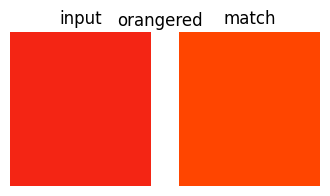

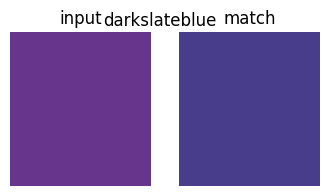

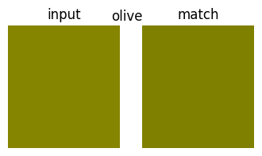

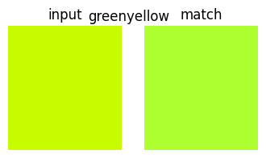

```python
def get_color_name(requested_colour):
        min_colours = {}
        for key, name in webcolors.CSS3_HEX_TO_NAMES.items():
            r_c, g_c, b_c = webcolors.hex_to_rgb(key)
            rd = (r_c - requested_colour[0]) ** 2
            gd = (g_c - requested_colour[1]) ** 2
            bd = (b_c - requested_colour[2]) ** 2
            min_colours[(rd + gd + bd)] = name
        closest_color = min_colours[min(min_colours.keys())]
        return closest_color

def show_color_selection(requested_colour):

    closest_name = get_color_name(requested_colour)
    similar_color = dict(webcolors.CSS3_NAMES_TO_HEX)[closest_name]

    fig, ax = plt.subplots(1, 2, figsize=(4, 2))

    # Check if the input is RGB array
    if (isinstance(requested_colour, list) or isinstance(requested_colour, tuple)) and len(requested_colour) == 3:
        requested_colour = [x/255 for x in requested_colour]  # Normalize to [0,1]

    rect = patches.Rectangle((0, 0), 1, 1, facecolor=requested_colour)
    ax[0].add_patch(rect)
    ax[0].axis('off')
    ax[0].set_title("input")

    rect = patches.Rectangle((0, 0), 1, 1, facecolor=similar_color)
    ax[1].add_patch(rect)
    ax[1].axis('off')
    ax[1].set_title(f"match")
    plt.suptitle(closest_name)

print("Exaples of sampled RGB colors and the closest CSS3 color name that is used to describe the color:")

requested_colour = (244,37,20)
show_color_selection(requested_colour)

requested_colour = (104,53,140)
show_color_selection(requested_colour)

requested_colour = (133,133,0)
show_color_selection(requested_colour)

requested_colour = (200,250,0)
show_color_selection(requested_colour)
```

## Explorative data analysis of generated data

The visualisations that are used to describe the generated data sets *train_256*, *val_256* and *test_256* are created below.

```
Sampled values from the train set
```

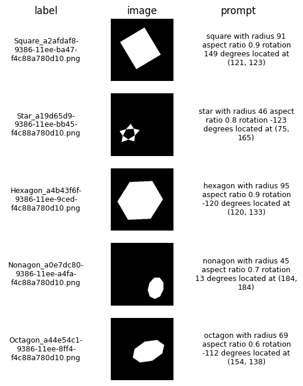

```python
path_train = "data/train256/"
path_val = "data/val256/"
path_test = "data/test256/"

df_train = pd.read_csv(os.path.join(path_train, "labels.csv"))

image_dir = os.path.join(path_train, "images")
filenames = os.listdir(image_dir)

fig, axs = plt.subplots(5, 3, figsize=(6,8))
for i in range(5):
    filename = filenames[random.randint(0, len(filenames))]
    sub_df = df_train.loc[df_train["file"].str.endswith(filename)].reset_index(drop=True)
    prompt = sub_df.at[0, "prompt"]
    image = imread(os.path.join(image_dir, filename))

    fname = textwrap.fill(filename, 18)
    axs[i, 0].text(0.5, 0.5, fname, size=9, ha='center', va='center')
    axs[i, 0].axis('off')  # Hide axes on the text subplot


    axs[i, 1].imshow(image)
    axs[i, 1].axis('off')  # Hide axes on the image subplot

    prompt = textwrap.fill(prompt, 27)
    axs[i, 2].text(0.6, 0.5, prompt, size=9, ha='center', va='center')
    axs[i, 2].axis('off')  # Hide axes on the text subplot

    axs[0, 0].set_title("label")
    axs[0, 1].set_title("image")
    axs[0, 2].set_title("prompt")

print("Sampled values from the train set")
plt.show()
```

### Nr of samples per shape

```python
labels_train = pd.read_csv(os.path.join(path_train, "labels.csv"))
labels_val = pd.read_csv(os.path.join(path_val, "labels.csv"))
labels_test = pd.read_csv(os.path.join(path_test, "labels.csv"))

image_dir = os.path.join(path_train, "images")
filenames = os.listdir(image_dir)

print("Training set")
print(labels_train["shape_name"].value_counts())
```

```
Training set
shape_name
triangle    1000
circle      1000
heptagon    1000
octagon     1000
hexagon     1000
square      1000
nonagon     1000
pentagon    1000
star        1000
Name: count, dtype: int64
```

```python
print("\nValidation set")
print(labels_val["shape_name"].value_counts())
```

```
Validation set
shape_name
triangle    5
circle      5
heptagon    5
octagon     5
hexagon     5
square      5
nonagon     5
pentagon    5
star        5
Name: count, dtype: int64
```

```python
print("\nTest set")
print(labels_test["shape_name"].value_counts())
```

```
Test set
shape_name
triangle    12
circle      12
heptagon    12
octagon     12
hexagon     12
square      12
nonagon     12
pentagon    12
star        12
Name: count, dtype: int64
```

### Value distributions

#### Shape diameter

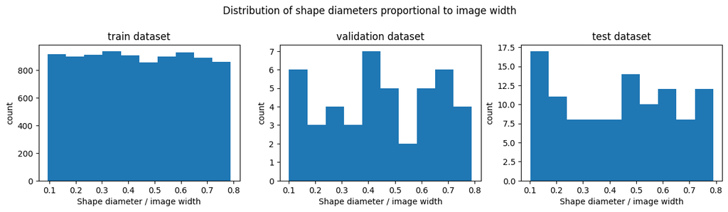

```python
labels_train["proportional_diameter"] = (labels_train["radius"] / labels_train["im_res"]) * 2
labels_val["proportional_diameter"] = (labels_val["radius"] / labels_val["im_res"]) * 2
labels_test["proportional_diameter"] = (labels_test["radius"] / labels_test["im_res"]) * 2

titles = ["train dataset", "validation dataset", "test dataset"]
labels = [labels_train, labels_val, labels_test]
fig, axs = plt.subplots(1,3, figsize=(15,3))

for i, (title, label) in enumerate(zip(titles, labels)):
    axs[i].hist(label["proportional_diameter"])
    axs[i].set_xlabel("Shape diameter / image width")
    axs[i].set_ylabel("count")
    axs[i].set_title(title)

plt.suptitle("Distribution of shape diameters proportional to image width", y=1.1)
plt.show()
```

#### Position

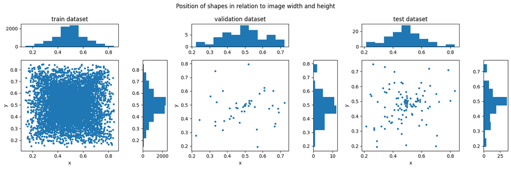

```python
fig, axs = plt.subplots(2,6,figsize=(15,5), gridspec_kw={'height_ratios': [1, 4], 'width_ratios': [4, 1, 4, 1, 4, 1]})

labels_train["x_prop"] = labels_train["x"] / 256
labels_val["x_prop"] = labels_val["x"] / 256
labels_test["x_prop"] = labels_test["x"] / 256

labels_train["y_prop"] = labels_train["y"] / 256
labels_val["y_prop"] = labels_val["y"] / 256
labels_test["y_prop"] = labels_test["y"] / 256


axs[0, 0].hist(labels_train["x_prop"])
axs[1, 0].scatter(labels_train["x_prop"], labels_train["y_prop"], marker=".")
axs[1, 1].hist(labels_train["y_prop"], orientation="horizontal")

axs[0, 2].hist(labels_val["x_prop"])
axs[1, 2].scatter(labels_val["x_prop"], labels_val["y_prop"], marker=".")
axs[1, 3].hist(labels_val["y_prop"], orientation="horizontal")

axs[0, 4].hist(labels_test["x_prop"])
axs[1, 4].scatter(labels_test["x_prop"], labels_test["y_prop"], marker=".")
axs[1, 5].hist(labels_test["y_prop"], orientation="horizontal")

axs[0, 0].set_title("train dataset")
axs[0, 2].set_title("validation dataset")
axs[0, 4].set_title("test dataset")


axs[0, 1].axis("off")
axs[0, 3].axis("off")
axs[0, 5].axis("off")

axs[1, 0].set_xlabel("x")
axs[1, 2].set_xlabel("x")
axs[1, 4].set_xlabel("x")

axs[1, 0].set_ylabel("y")
axs[1, 2].set_ylabel("y")
axs[1, 4].set_ylabel("y")


plt.suptitle("Position of shapes in relation to image width and height")
plt.tight_layout()
plt.show()
```

#### Rotation

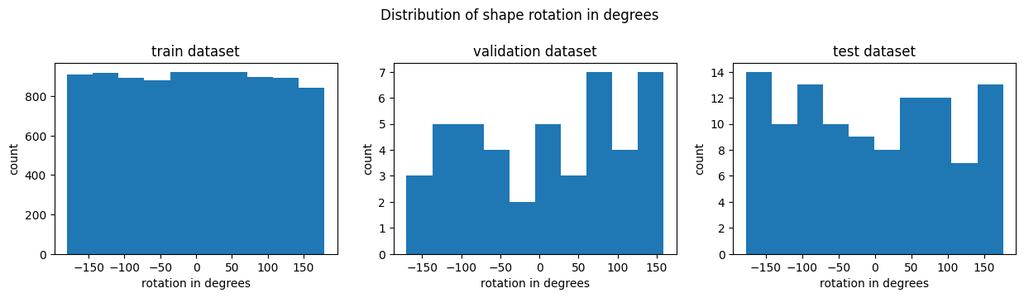

```python
titles = ["train dataset", "validation dataset", "test dataset"]
labels = [labels_train, labels_val, labels_test]
fig, axs = plt.subplots(1,3, figsize=(15,3))

for i, (title, label) in enumerate(zip(titles, labels)):
    axs[i].hist(label["rotation"] * 180 / np.pi)
    axs[i].set_xlabel("rotation in degrees")
    axs[i].set_ylabel("count")
    axs[i].set_title(title)

plt.suptitle("Distribution of shape rotation in degrees", y=1.1)
plt.show()




# plt.hist(labels_train["rotation"] * 180 / np.pi)
# plt.title("Distribution of shape rotation in degrees")
# plt.xlabel("rotation in degrees")
# plt.ylabel("count")
# plt.show()
```

#### Aspect Ratio

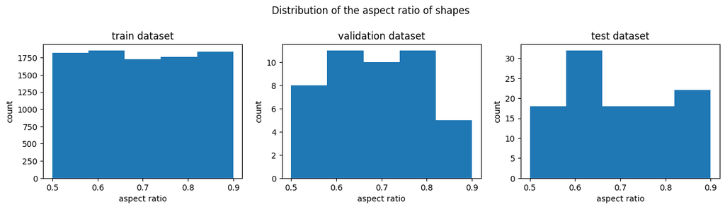

```python
titles = ["train dataset", "validation dataset", "test dataset"]
labels = [labels_train, labels_val, labels_test]
fig, axs = plt.subplots(1,3, figsize=(15,3))

for i, (title, label) in enumerate(zip(titles, labels)):
    axs[i].hist(label["aspect_ratio"], bins=5)
    axs[i].set_xlabel("aspect ratio")
    axs[i].set_ylabel("count")
    axs[i].set_title(title)

plt.suptitle("Distribution of the aspect ratio of shapes", y=1.1)
plt.show()
```